# Factorial experiment example - weight gain

# Problem

(source: Crawley, The R book)

Our example comes from a farm-scale trial of animal diets. There are two factors: diet and supplement.

Diet is a factor with three levels: barley, oats and wheat.

Supplement is a factor with four levels: agrimore, control, supergain and supersupp.

The response variable is weight gain after 6 weeks.

```r
weights <- read.csv("data/growth2.txt", sep="\t")
head(weights)
```

```
##   supplement  diet     gain
## 1  supergain wheat 17.37125
## 2  supergain wheat 16.81489
## 3  supergain wheat 18.08184
## 4  supergain wheat 15.78175
## 5    control wheat 17.70656
## 6    control wheat 18.22717
```

```r
table(weights$diet, weights$supplement)
```

```
##
##          agrimore control supergain supersupp
##   barley        4       4         4         4
##   oats          4       4         4         4
##   wheat         4       4         4         4
```

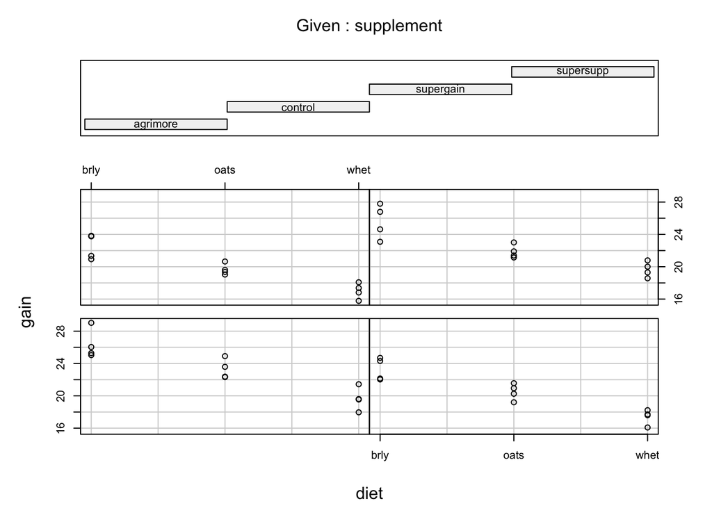

```r
with(weights,
     coplot(gain ~ diet|supplement,rows=2))
```

We will perform an analysis of variance including a factor for the interaction between diet and supplement:

```r
model<-aov(gain~diet*supplement, data = weights)
summary(model)
```

```
##                 Df Sum Sq Mean Sq F value   Pr(>F)
## diet             2 287.17  143.59   83.52 3.00e-14 ***
## supplement       3  91.88   30.63   17.82 2.95e-07 ***
## diet:supplement  6   3.41    0.57    0.33    0.917
## Residuals       36  61.89    1.72
## ---
## Signif. codes:  0 '***' 0.001 '**' 0.01 '*' 0.05 '.' 0.1 ' ' 1
```

The ANOVA table shows that there is no hint of any interaction between the two explanatory variables (p=0.917): the effects of diet and supplement are additive.

Let’s check for this graphically…

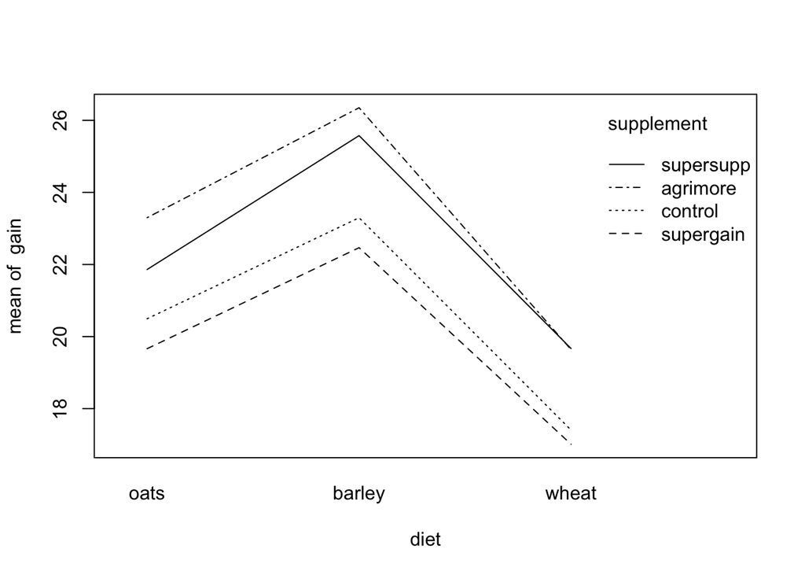

```r
weights$diet <- relevel(weights$diet, ref="oats")
with(weights, interaction.plot(diet,supplement, response = gain))
```

Since interactions are not significant, we can consider simplifying our model:

```r
model2 <- aov(gain~diet + supplement, data = weights)
summary(model2)
```

```
##             Df Sum Sq Mean Sq F value   Pr(>F)
## diet         2 287.17  143.59   92.36 4.20e-16 ***
## supplement   3  91.88   30.63   19.70 3.98e-08 ***
## Residuals   42  65.30    1.55
## ---
## Signif. codes:  0 '***' 0.001 '**' 0.01 '*' 0.05 '.' 0.1 ' ' 1
```

Which one is best?

The second model is much simpler than the first one:

```r
summary.lm(model)
```

```
##
## Call:
## aov(formula = gain ~ diet * supplement, data = weights)
##
## Residuals:
##      Min       1Q   Median       3Q      Max
## -2.48756 -1.00368 -0.07452  1.03496  2.68069
##
## Coefficients:
##                               Estimate Std. Error t value Pr(>|t|)
## (Intercept)                    26.3485     0.6556  40.191  < 2e-16 ***
## dietoats                       -3.0501     0.9271  -3.290 0.002248 **
## dietwheat                      -6.7094     0.9271  -7.237 1.61e-08 ***
## supplementcontrol              -3.0518     0.9271  -3.292 0.002237 **
## supplementsupergain            -3.8824     0.9271  -4.187 0.000174 ***
## supplementsupersupp            -0.7732     0.9271  -0.834 0.409816
## dietoats:supplementcontrol      0.2471     1.3112   0.188 0.851571
## dietwheat:supplementcontrol     0.8183     1.3112   0.624 0.536512
## dietoats:supplementsupergain    0.2470     1.3112   0.188 0.851652
## dietwheat:supplementsupergain   1.2557     1.3112   0.958 0.344601
## dietoats:supplementsupersupp   -0.6650     1.3112  -0.507 0.615135
## dietwheat:supplementsupersupp   0.8024     1.3112   0.612 0.544381
## ---
## Signif. codes:  0 '***' 0.001 '**' 0.01 '*' 0.05 '.' 0.1 ' ' 1
##
## Residual standard error: 1.311 on 36 degrees of freedom
## Multiple R-squared:  0.8607, Adjusted R-squared:  0.8182
## F-statistic: 20.22 on 11 and 36 DF,  p-value: 3.295e-12
```

```r
summary.lm(model2)
```

```
##
## Call:
## aov(formula = gain ~ diet + supplement, data = weights)
##
## Residuals:
##      Min       1Q   Median       3Q      Max
## -2.30792 -0.85929 -0.07713  0.92052  2.90615
##
## Coefficients:
##                     Estimate Std. Error t value Pr(>|t|)
## (Intercept)          23.0302     0.4408  52.242  < 2e-16 ***
## dietbarley            3.0928     0.4408   7.016 1.38e-08 ***
## dietwheat            -2.8975     0.4408  -6.573 5.96e-08 ***
## supplementcontrol    -2.6967     0.5090  -5.298 4.03e-06 ***
## supplementsupergain  -3.3815     0.5090  -6.643 4.72e-08 ***
## supplementsupersupp  -0.7274     0.5090  -1.429     0.16
## ---
## Signif. codes:  0 '***' 0.001 '**' 0.01 '*' 0.05 '.' 0.1 ' ' 1
##
## Residual standard error: 1.247 on 42 degrees of freedom
## Multiple R-squared:  0.8531, Adjusted R-squared:  0.8356
## F-statistic: 48.76 on 5 and 42 DF,  p-value: < 2.2e-16
```

We can compare them directly:

```r
anova(model,model2)
```

```
## Analysis of Variance Table
##
## Model 1: gain ~ diet * supplement
## Model 2: gain ~ diet + supplement
##   Res.Df    RSS Df Sum of Sq      F Pr(>F)
## 1     36 61.890
## 2     42 65.296 -6   -3.4058 0.3302 0.9166
```

The second model is simpler and it is not significantly worst than the first model, so we go for model2 and we try to interpret it.

Go back and look again at the summary of model2:

- the barley and wheat diet are statistically different, in terms of weight gain, from the oats diet, but what about the difference between wheat and barley?
- it’s the same for the control and supergain supplements with respect to agrimore, but what about the difference between them? and with supersupp??

Let’s check with a TukeyHSD test:

```r
TukeyHSD(model2)
```

```
##   Tukey multiple comparisons of means
##     95% family-wise confidence level
##
## Fit: aov(formula = gain ~ diet + supplement, data = weights)
##
## $diet
##                   diff       lwr       upr p adj
## barley-oats   3.092817  2.021817  4.163817 0e+00
## wheat-oats   -2.897481 -3.968481 -1.826481 2e-07
## wheat-barley -5.990298 -7.061298 -4.919297 0e+00
##
## $supplement
##                           diff        lwr        upr     p adj
## control-agrimore    -2.6967005 -4.0583332 -1.3350677 0.0000234
## supergain-agrimore  -3.3814586 -4.7430914 -2.0198259 0.0000003
## supersupp-agrimore  -0.7273521 -2.0889849  0.6342806 0.4888738
## supergain-control   -0.6847581 -2.0463909  0.6768746 0.5400389
## supersupp-control    1.9693484  0.6077156  3.3309811 0.0020484
## supersupp-supergain  2.6541065  1.2924737  4.0157392 0.0000307
```

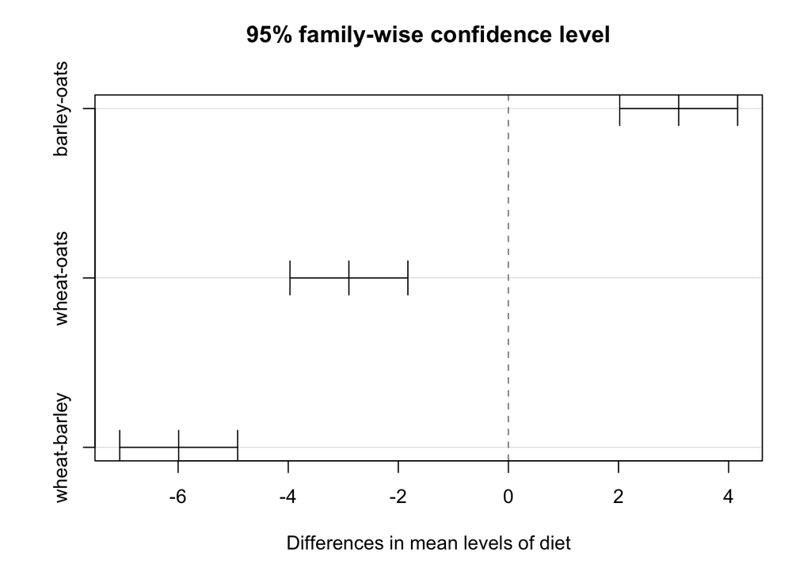

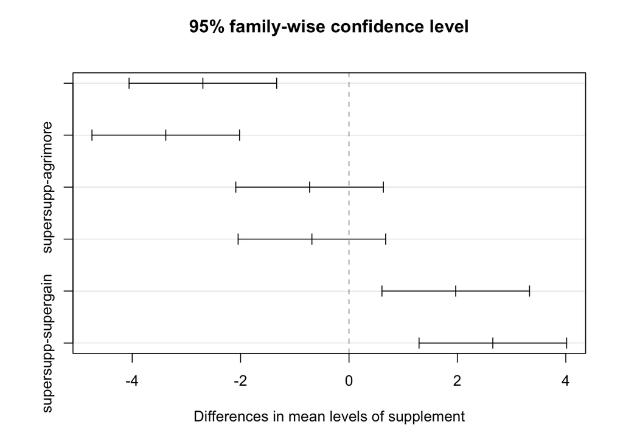

```r
plot(TukeyHSD(model2))
```

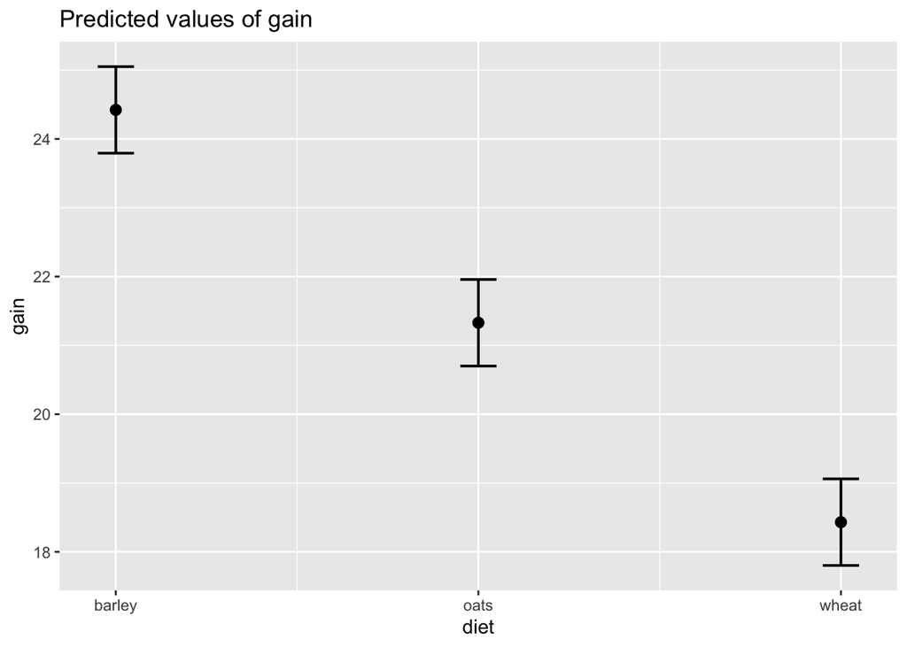

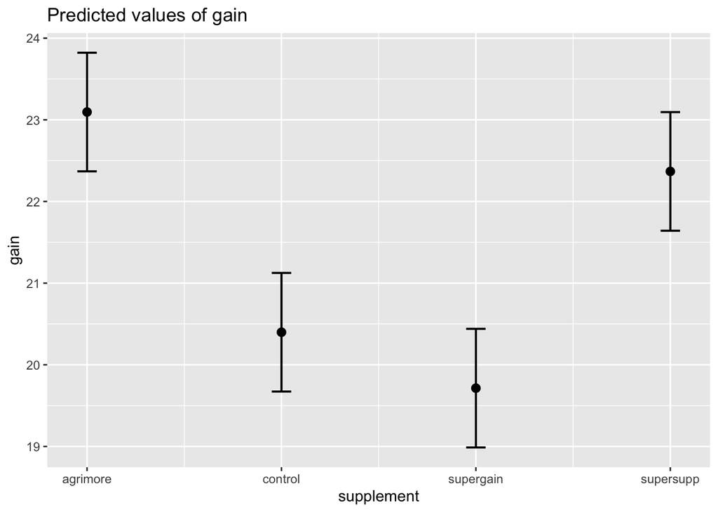

```r
library(sjPlot)
# plot_model(model2, type = "diag")
plot_model(model2, type="eff")
```

check here for an example with a significant interaction: https://cran.r-project.org/web/packages/jtools/vignettes/categorical.html

# Interactions with at least one continuous predictor

(source: https://cran.r-project.org/web/packages/jtools/vignettes/interactions.html)

This famous (Fisher’s or Anderson’s) iris data set gives the measurements in centimeters of the variables sepal length and width and petal length and width, respectively, for 50 flowers from each of 3 species of iris. The species are Iris setosa, versicolor, and virginica.

```r
data(iris)
head(iris)
```

```
##   Sepal.Length Sepal.Width Petal.Length Petal.Width Species
## 1          5.1         3.5          1.4         0.2  setosa
## 2          4.9         3.0          1.4         0.2  setosa
## 3          4.7         3.2          1.3         0.2  setosa
## 4          4.6         3.1          1.5         0.2  setosa
## 5          5.0         3.6          1.4         0.2  setosa
## 6          5.4         3.9          1.7         0.4  setosa
```

Please note that here we use `lm` rather than `aov`:

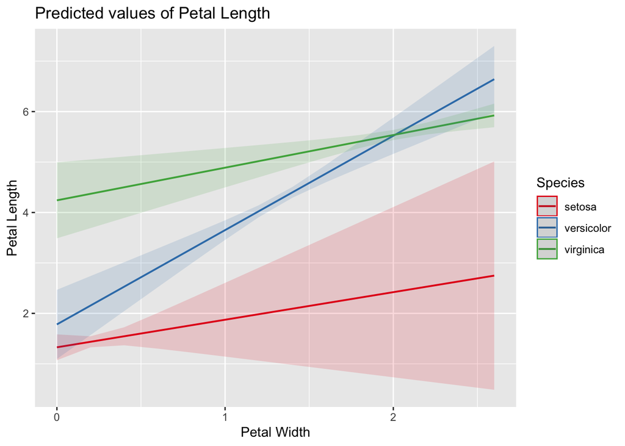

```r
fitiris <- lm(Petal.Length ~ Petal.Width * Species, data = iris)
library(jtools)
plot_model(fitiris, type="int")
```